# Pràctica1

Àlex Soler

2024-04-08

## Estadístics bàsics i estimacions

### Lectura de les dades i visualització de les mostres

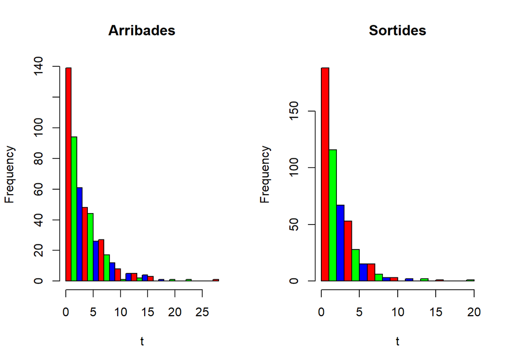

```r
A<-read.table("A4.DAT",header=T,as.is=T)
S<-read.table("S10.DAT",header=T,as.is=T)
par(mfrow=c(1,2))
hist(A$x,20,col=rainbow(n=3),main="Arribades",xlab="t")
hist(S$y,20,col=rainbow(n=3),main="Sortides",xlab="t")
```

Graficant les mostres, podem veure com aparentment semblen dos distribucions exponencials. A continuació veiem algunes estadístiques bàsiques, primer per les arribades i després per les sortides:

```r
summary(A)
```

```
##        x
##  Min.   : 0.0066
##  1st Qu.: 0.8949
##  Median : 2.2428
##  Mean   : 3.3693
##  3rd Qu.: 4.6842
##  Max.   :27.1466
```

```r
summary(S)
```

```
##        y
##  Min.   : 0.0017
##  1st Qu.: 0.6192
##  Median : 1.4071
##  Mean   : 2.1738
##  3rd Qu.: 3.0740
##  Max.   :19.7275
```

### Distribució de la hipòtesi nul·la

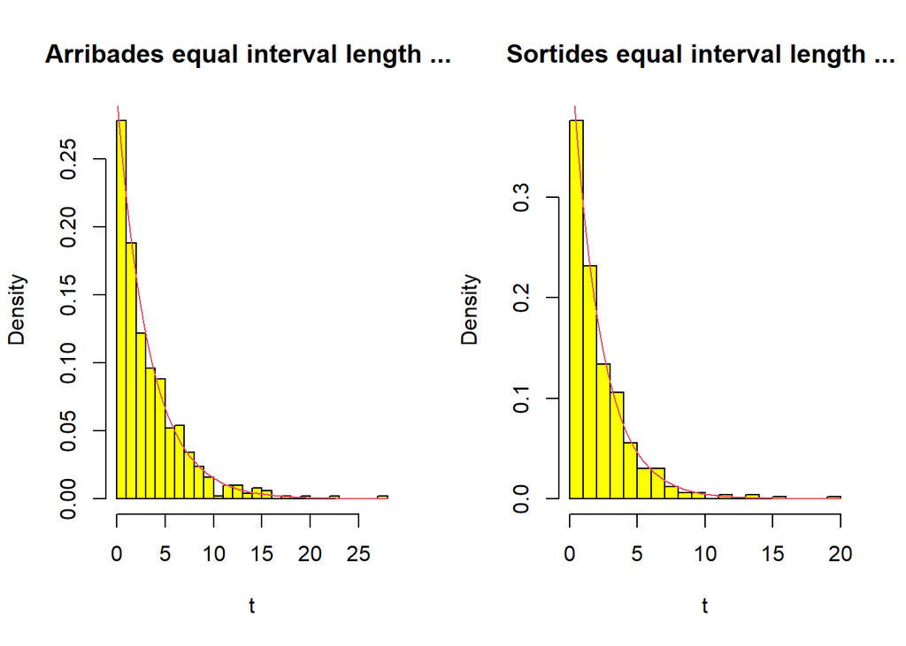

```r
mm1<-mean(A$x)
mm2<-mean(S$y)
Arate<-1/mm1
Srate<-1/mm2
rho<-Arate/Srate
par(mfrow=c(1,2))
hist(A$x,freq=FALSE,breaks=25,col="yellow",main="Arribades equal interval length ... ",xlab="t") # opcio freq=FALSE canvia l'escala y a densitats i no a freqüencies.
curve(dgamma(x,shape=1,scale=mm1),col=2,add=T)
hist(S$y,freq=FALSE,breaks=25,col="yellow",main="Sortides equal interval length ... ",xlab="t") # opcio freq=FALSE canvia l'escala y a densitats i no a freqüencies.
curve(dgamma(x,shape=1,scale=mm2),col=2,add=T)
```

En els gràfics podem comprovar com les dades semblen ajustar-se prou bé a una distribució exponencial de paràmetres 0.2968 i 0.46 respectivament (les corbes vermelles segueixen distribucions exponencials). Tot i així haurem de fer el test per comprovar-ho.  
Les estimacions fetes son:  
$\hat{\lambda}$=0.2968  
$\hat{\mu}$= 0.46  
$\hat{\rho}$= 0.6452  
En el cas que sigui una exponencial, existiria estat estacionari ja que l’estimació de $\rho$ és més petit que 1.

## Intervals de confiança al 95% per $\lambda$ $\mu$ i $\rho$

Sabem que per l’interval de $\lambda$ i $\mu$ hem d’utilitzar la distribució chi-quadrat amb 2n graus de llibertad i per la $\rho$ al ser quocient de chi-quadrats entre els seus graus de llibertad, aquesta seguirà una fisher amb 2n i 2n graus de llibertad.

```r
n<-length(A$x)
lambda_est<-Arate
mu_est<-Srate
x_inf<-qchisq(0.025,2*n)
x_sup<-qchisq(0.975,2*n)
ic_lambda_inf<-x_inf*lambda_est/(2*n)
ic_lambda_sup<-x_sup*lambda_est/(2*n)

ic_mu_inf<-x_inf*mu_est/(2*n)
ic_mu_sup<-x_sup*mu_est/(2*n)


rho_est<-lambda_est/mu_est
f_inf<-qf(0.025,2*n,2*n)
f_sup<-qf(0.975,2*n,2*n)
ic_rho_inf<-f_inf*rho_est
ic_rho_sup<-f_sup*rho_est
```

| Paràmetre | IC95%_inferior | IC95%_superior |
| --- | --- | --- |
| $\lambda$ | 0.2713526 | 0.323374 |
| $\mu$ | 0.420584 | 0.5012148 |
| $\rho$ | 0.5699225 | 0.7303763 |

## Gràfic i test chi-quadrat

```r
sequence<-seq(0,1,by=0.04)
#Arribades
perdist1<-qexp(sequence,rate=Arate)
perdist1
```

```
##  [1]  0.0000000  0.1375399  0.2809343  0.4307038  0.5874418  0.7518285
##  [7]  0.9246489  1.1068153  1.2993969  1.5036569  1.7211039  1.9535588
## [13]  2.2032478  2.4729324  2.7660963  3.0872210  3.4422079  3.8390494
## [19]  4.2889513  4.8083249  5.4226135  6.1744420  7.1437174  8.5098345
## [25] 10.8452270        Inf
```

```r
perdist1[26]<-30
perdist1
```

```
##  [1]  0.0000000  0.1375399  0.2809343  0.4307038  0.5874418  0.7518285
##  [7]  0.9246489  1.1068153  1.2993969  1.5036569  1.7211039  1.9535588
## [13]  2.2032478  2.4729324  2.7660963  3.0872210  3.4422079  3.8390494
## [19]  4.2889513  4.8083249  5.4226135  6.1744420  7.1437174  8.5098345
## [25] 10.8452270 30.0000000
```

```r
#Sortides
perdist2<-qexp(sequence,rate=Srate)
perdist2
```

```
##  [1] 0.00000000 0.08873805 0.18125331 0.27788168 0.37900598 0.48506508
##  [7] 0.59656544 0.71409570 0.83834554 0.97013016 1.11042273 1.26039808
## [13] 1.42149254 1.59548781 1.78463143 1.99181483 2.22084546 2.47687991
## [19] 2.76714784 3.10223756 3.49856459 3.98362967 4.60898732 5.49037942
## [25] 6.99712918        Inf
```

```r
perdist2[26]<-20
perdist2
```

```
##  [1]  0.00000000  0.08873805  0.18125331  0.27788168  0.37900598  0.48506508
##  [7]  0.59656544  0.71409570  0.83834554  0.97013016  1.11042273  1.26039808
## [13]  1.42149254  1.59548781  1.78463143  1.99181483  2.22084546  2.47687991
## [19]  2.76714784  3.10223756  3.49856459  3.98362967  4.60898732  5.49037942
## [25]  6.99712918 20.00000000
```

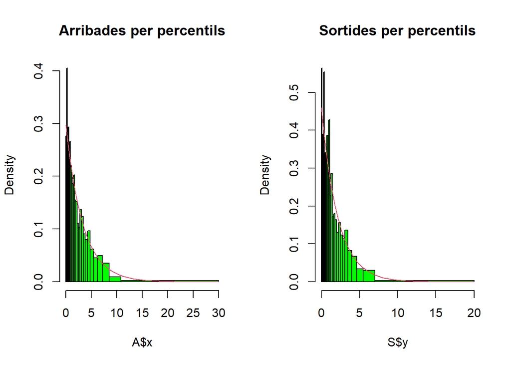

```r
par(mfrow=c(1,2))
hist(A$x,freq=FALSE,breaks=perdist1,col="green",main="Arribades per percentils")
curve(dgamma(x,shape=1,scale=mm1),col=2,add=T)
hist(S$y,freq=FALSE,breaks=perdist2,col="green",main="Sortides per percentils")
curve(dgamma(x,shape=1,scale=mm2),col=2,add=T)
```

### Test chi-quadrat

Pel test chi-quadrat és important comprovar que en cada interval creat hi hagin més de 5 observacions. Per això primer mirarem si hi ha algun interval que tingui 5 o menys observacions, si fos així posariem menys intervals per a que fossin més grans i així augmentar les observacions en cadascun.

```r
# Chi squared test
dsample1<-cut(A$x,breaks=perdist1,include.lowest = T)
dsample2<-cut(S$y,breaks=perdist2,include.lowest = T)

sum(table(dsample1)<=5)
```

```
## [1] 0
```

```r
sum(table(dsample2)<=5)
```

```
## [1] 0
```

```r
iobs1<-as.vector(table(dsample1))            # Obs in the groups defined by nb intervals-percentiles
pexp1<-as.vector(rep(1/25,25))              # Expected probability for each groups: sample size/nb intervals
iexp1<-n*pexp1                            # VALOR ESPERAT D'OBSERVACIONS

iobs2<-as.vector(table(dsample2))            # Obs in the groups defined by nb intervals-percentiles
pexp2<-as.vector(rep(1/25,25))              # Expected probability for each groups: sample size/nb intervals
iexp2<-n*pexp2                             # VALOR ESPERAT D'OBSERVACIONS

X2_1<-sum(((iobs1-iexp1)^2)/iexp1)
test_1<-chisq.test( iobs1,p=pexp1 )


X2_2<-sum(((iobs2-iexp2)^2)/iexp2)
test_2<-chisq.test( iobs2,p=pexp2 )
```

També representarem gràficament el número d’observacions per interval. És una forma més visual per estudiar la regularitat del número d’observacions distribuides sobre cada interval.

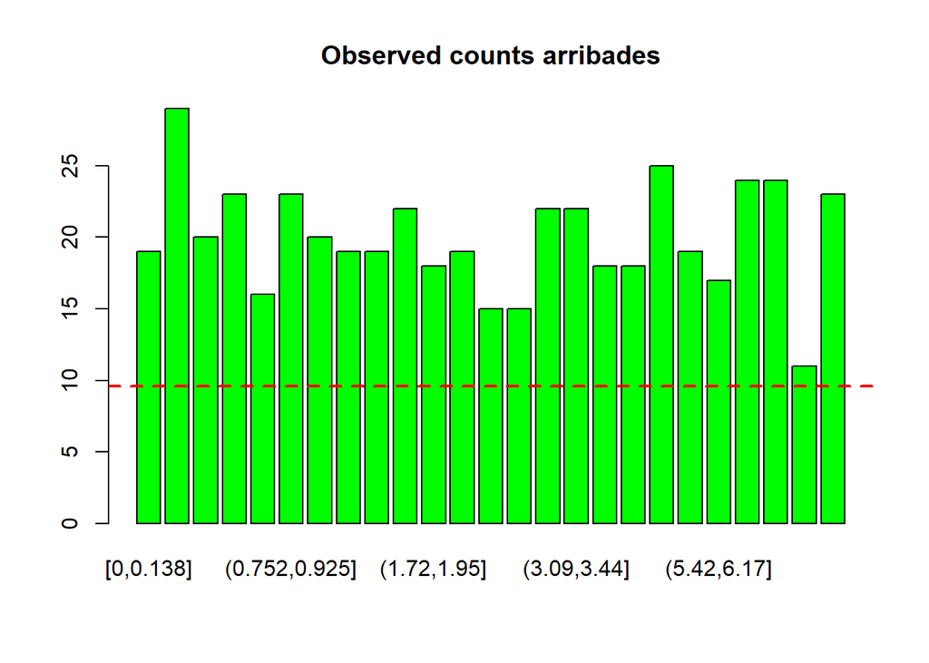

```r
barplot(table(dsample1),main="Observed counts arribades",col="green") # ES DIBUIXA UN DIAGRAMA DE BARRES QUE DONA IDEA DE LA REGULARITAT DEL Nº D'OBSERVACIONS DISTRIBUÏT SOBRE CADA INTERVAL
abline(h=240/25,col="red",lwd=2,lty=2)
```

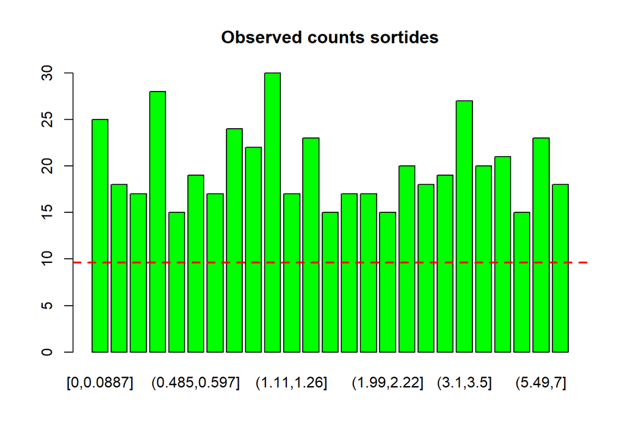

```r
barplot(table(dsample2),main="Observed counts sortides",col="green") # ES DIBUIXA UN DIAGRAMA DE BARRES QUE DONA IDEA DE LA REGULARITAT DEL Nº D'OBSERVACIONS DISTRIBUÏT SOBRE CADA INTERVAL
abline(h=240/25,col="red",lwd=2,lty=2)
```

Com la hipòtesis nul·la era que les mostres seguien una llei exponencial, al tenir p-valors superiors a 0.05 i no poder rebutjar la hipòtesis nul·la, podem concluir que hi ha suficient evidència estadística per creure que les dades d’arribades i de sortides segueixen lleis exponencials. Les dades obtingudes al test per cada cas son:  
- 17.5 com a estadístic del test per les arribades i 0.8265686 com a p-valor  
- 21.8 com a estadístic del test pels temps de servei i 0.5912028 com a p-valor